# Debugger demo guide

Author

Diogo Silva

# Introduction

The purpose of this guide is to demonstrate the usage of the debugger in four different ways:

1. Inside Jupyter Notebook with `%pdb`. Show all relevant pdb commands (w, d, u, p, c, b)
2. By adding `import pdb; pdb.set_trace()` inside our code.
3. By running a script with `python -m pdb script.py`
4. Inside an IDE, like VS Code, with debug mode.

# Interacting with the debugger

## Jupyter

- Demonstrate what we can do inside Jupyter.
- By adding %pdb, all cells run with the debugger on.
- If an exception occurs, the program will hang at that point, and we can interact with the debugger.

## With import

- By adding `import pdb; pdb.set_trace()` at any point in the code, the program will stop at the following line.
- We can then interact with the debugger at that point.

## Jupyter debug mdoe

- Enable debug mode in Jupyter, by click the bug button on the right top corner.

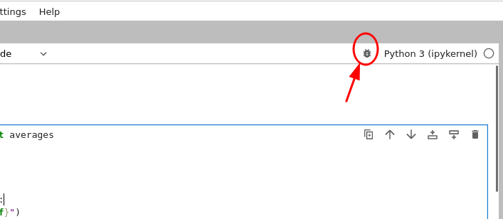

- This will show the debugging sidebar.

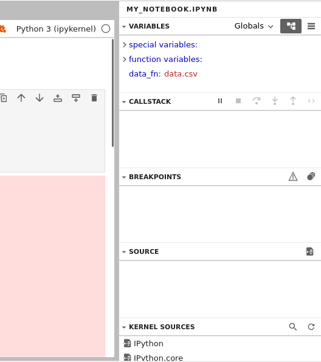

- Now you can set breakpoints, step through code, etc.

## `-m pdb`

- By executing our code with `python -m pdb script.py`, the debugger will be turned on by default.
- The program will start as if `import pdb; pdb.set_trace()` had been added to our script.
- This means the program will start and imediately stop in the first line, with a debugger prompt.

## With IDE

- Demonstrate running the script in VS Code in debug mode.
- Show how easier it is

# Support code for demo

Create the following file structure:

- my_example_fodler
  - mypackage (this is a folder)
    - `__init__.py`
    - `file_utils.py`
    - `stats.py`
  - `data.csv`
  - `script.py`
  - `my_notebook.ipynb`

## Content of `file_utils.py`

```python
from typing import List, Tuple
def read_csv(fn: str) -> List[Tuple[int, int]]:
    # csv = comma separated values
    data = []
    with open(fn) as f:
        for line in f:
            # split lines by comma
            v1,v2 = line.split(',')
            v1,v2 = float(v1), float(v2)
            data.append((v1,v2))

    return data
```

## Content of `stats.py`

```python
from .file_utils import read_csv

def averages(filename):
    '''
    This function receives the filename of a CSV file,
    reads the data for age and weight,
    averages each column and returns a dict with
    each average.
    inputs:
        string: path to the CSV file,
                expects file to be in CSV format and have 2 columns
    outputs:
        dict: with 2 keys "age" and "weight", with the averages
              of the CSV columns

    '''
    data = read_csv(filename)
    age_av = weights_av = None
    ages, weights = [], []
    for age, weight in data:
        ages.append(age)
        weights.append(weight)
    age_av = sum(ages) / len(ages)
    weight_av = sum(weights) / len(weights)
    return {"age": age_av, "weight": weights_av}
```

## Content of `script.py`

```python
from mypackage.stats import averages

data_fn = "data.csv"
avs = averages(data_fn)

print(f"Averages\t")
for col, av in avs.items():
    print(f"{col}\t{av :.2f}")
```

## Content of `my_notebook.ipynb`

```
{
 "cells": [
  {
   "cell_type": "markdown",
   "id": "805570c7-5692-49f4-ba64-e3485f440776",
   "metadata": {},
   "source": [
    "# Debug"
   ]
  },
  {
   "cell_type": "code",
   "execution_count": null,
   "id": "3f9827a9-b91e-4c68-bc82-ce87a26a5614",
   "metadata": {},
   "outputs": [],
   "source": [
    "from mypackage.stats import averages\n",
    "\n",
    "data_fn = \"data.csv\"\n",
    "avs = averages(data_fn)\n",
    "print(f\"Averages\\t\")\n",
    "for col, av in avs.items():\n",
    "    print(f\"{col}\\t{av :.2f}\")"
   ]
  },
  {
   "cell_type": "markdown",
   "id": "32f1863f-0cff-4f36-b9a3-e846af5a8d13",
   "metadata": {},
   "source": [
    "We should definetely fix this. It's helpful to know the values of the variables when the program failed."
   ]
  },
  {
   "cell_type": "markdown",
   "id": "165b2134-3801-41a8-b0c1-31be1c188977",
   "metadata": {},
   "source": [
    "Turn on the Python dubegger and rerun the cell above."
```

[output cut: 28 more lines]

```
   "codemirror_mode": {
    "name": "ipython",
    "version": 3
   },
   "file_extension": ".py",
   "mimetype": "text/x-python",
   "name": "python",
   "nbconvert_exporter": "python",
   "pygments_lexer": "ipython3",
   "version": "3.10.12"
  }
 },
 "nbformat": 4,
 "nbformat_minor": 5
}
```

## Content of `data.csv`

```
age,weight
23,70.4
25,80.0
27,55,6
```